# hw1

Liming Ning

2022/1/16

```r
rm(list = ls())
```

# 1 Case Study 1: Audience Size

## 1.1 Data Preparation

### 1.1.1 Cleaning

```r
# selection
talkdata = fread("data/Survey_results_final.csv", encoding = "UTF-8")
talkdata.selected =
  talkdata[,.(age = Answer.Age, # Note: some answers in Age are not numeric. Therefore, type of Answer.Age is character.
              gender = Answer.Gender,
              education = Answer.Education,
              income = Answer.HouseHoldIncome,
              sirius = `Answer.Sirius Radio`,
              wharton = `Answer.Wharton Radio`,
              worktime = WorkTimeInSeconds)]
```

The variable selection and renaming are trivial, so we do not include them in the html file.

**The first ten rewards**

```r
talkdata$Reward[1:10] # question: 5 cents or 10 cents?
```

One issue: the reward in the description section in the homework is 0.1, but the reward variable in the data is actually 0.05. Maybe the description is wrong.

**Suspicious ages**

```r
# detect suspicious observations
## age
talkdata.selected[!age %in% 10:100] # automatic type coercion when matching
talkdata.selected[age == "Eighteen (18)", age := "18"] # imputation
talkdata.selected[age == "27`", age := "27"] # imputation
talkdata.selected = talkdata.selected[age %in% 10:100] # delete NAs
talkdata.selected[,age := as.numeric(age)]
```

We detect six suspicious observations in ages. *Eighteen (18)* and *27`* are irregular but valid responses, so we impute in their regular forms; other four cannot be identified, so we exclude them in the following analysis.

**Suspicious gender**

```r
## gender
unique(talkdata.selected$gender)
talkdata.selected[!gender %in% c("Male","Female")]
talkdata.selected = talkdata.selected[gender != ""] # delete blanks
```

All six observations detected suspicious in gender are all missing. Although other values for these six observations are not missing, we still exclude them. Our justification is that these observations cannot provide information in the following analysis regarding gender. An alternative is that we do not exclude them, but actually it makes almost no difference because the relative number of samples are quite small.

**Suspicious education**

```r
## education
unique(talkdata.selected$education)
talkdata.selected = talkdata.selected[!education %in% c("Other","select one")] # delete because they are meaningless
```

It’s plausible that the first five options in education can cover all education levels. Thus the last two options can be considered as not informative, enough for the justification of exclusion.

**Suspicious income, sirius and wharton**

```r
## income
unique(talkdata.selected$income)
talkdata.selected = talkdata.selected[income != ""] # delete blanks
```

```r
## sirius
unique(talkdata.selected$sirius)
talkdata.selected = talkdata.selected[sirius != ""] # delete blanks
```

```r
## wharton
unique(talkdata.selected$wharton)
talkdata.selected = talkdata.selected[wharton != ""] # delete blanks
talkdata.selected[sirius == "No" & wharton == "Yes"] # These two are weird. Delete
talkdata.selected = talkdata.selected[!(sirius == "No" & wharton == "Yes")]
```

We delete all observations with at least one missing in income, sirius and wharton.

One important finding is that two people fill in “Yes” in wharton while “No” in sirius. This should not happen under our survey setting. It indicates that maybe some surveyors do the survey causally, which casts some doubt on the quality of the survey.

```r
fwrite(talkdata.selected,"data/talkdata_cleaned.csv",row.names = F)
## worktime: automatically recorded.
# possible improvements: use skimr. get summary stats in one go and make imputation/dropping them.
# alternatives: do not delete some obs which seems to be valid expect for some missings/errors while we're not running a regression with the covariates
```

```r
rm(list = ls())
```

### 1.1.2 Summary stats

**Integer variables**

```r
# age and worktime, integer
talkdata.selected = fread("data/talkdata_cleaned.csv",encoding = "UTF-8")
age.stat = talkdata.selected %>%
  summarise(mean = mean(age),min = min(age),median = median(age),max = max(age),"std. dev." = sd(age))
worktime.stat = talkdata.selected %>%
  summarise(mean = mean(worktime),min = min(worktime),median = median(worktime),max = max(worktime), "std. dev." = sd(worktime))
cont.var.stat = rbind(age.stat,worktime.stat)
rownames(cont.var.stat) = c("age","worktime")
talkdata.size = nrow(talkdata.selected)
kbl(cont.var.stat, caption = "Summary Statistics for Non-categorical Variables", digits = 2, booktabs = T,
    align = "lccccc") %>%
  kable_styling(latex_options = c("HOLD_position"))%>%
   footnote(general = paste("The table reports the summary statistics for non-categorical variables in the talkshow data. The valid sample size is ",talkdata.size,".",sep = ""),
            threeparttable = T)

age.hist = ggplot(talkdata.selected,aes(x=age))+
  geom_histogram()+
  theme_bw()+
  labs(title = "Histogram for Ages")
worktime.hist = ggplot(talkdata.selected,aes(x=worktime))+
  geom_histogram()+
  theme_bw()+
  labs(title = "Histogram for Worktime")
plot_grid(age.hist,worktime.hist,nrow = 1) # right-skewed
```

For the two integer variables age and worktime, we report their summary statistics table and histograms. Both variables are right-skewed. The valid sample size is 1723. We can see that most participants finish this survey with half a minute; also they are young, mostly aging from 20 to 35, possibly because they are more familiar with the Internet.

**Categorical variables**

```r
# categorical variables
## mapping
keywords.edu = data.table(education = unique(talkdata.selected$education))
keywords.edu[,order := c(3,5,4,2,1)]
keywords.edu = keywords.edu[order(order)]
for (i in 1:nrow(keywords.edu)) {
  talkdata.selected[education==keywords.edu$education[i],education:=keywords.edu$order[i]]
} # for education

keywords.income = data.table(income = unique(talkdata.selected$income))
keywords.income[,order := c(3,2,4,6,1,5)]
keywords.income = keywords.income[order(order)]
for (i in 1:nrow(keywords.income)) {
  talkdata.selected[income==keywords.income$income[i],income:=keywords.income$order[i]]
} # for income

## plots
get.bar = function(data,varname,x.label = varname,y.label = "count",...){

  ggplot(data,aes(x=eval(parse(text = varname))))+
    geom_bar(...)+
    xlab(x.label)+
    theme_bw()+
    labs(title = paste("Barplot of ",varname,sep = ""))
}

bar.list = list()
key.catevar = c("gender","education","income","sirius","wharton")
for (i in 1:length(key.catevar)) {
  bar.list[[i]] = get.bar(talkdata.selected,key.catevar[i])
}
plot_grid(plotlist = bar.list,nrow = 2)
```

We illustrate the barplots of five categorical variables: gender, education, income, sirius and wharton. **Notes**: We map the education and income levels into integers for better exhibition. For education, 1 means *less than 12 years; no high school diploma*, 2 means *High school graduate (or equivalent)*, 3 means *Some college, no diploma; or Associate’s degree*, 4 means *Bachelor’s degree or other 4-year degree*, 5 means *Graduate or professional degree*. For income, 1 means *Less than $15,000*, 2 means *$15,000 - $30,000*, 3 means *$30,000 - $50,000*, 4 means *$50,000 - $75,000*, 5 means *$75,000 - $150,000*, 6 means *Above $150,000*.

The key variables, sirius and wharton are of our primary interest. Over two thirds of the participants have ever listened to Sirius Radio, indicating that the distribution of the surveys is not inefficient – what we care about is the answer to wharton conditional on a “Yes” in sirius.

As for the covariates, it is revealed that the number of males is significantly larger than that of females among the surveyors. Their education levels are generally not high: few of them have a degree higher than bachelor. the income levels of the surveyors concentrate on the interval of $15,000 - $75,000 in 2014. It is worth noting that a considerable proportion of surveyors earn less than $15,000 per year in 2014. The implication is, the sample is affected by self-selection bias, because only people registering as workers in MTurk are exposed to this survey. People with low income and low education level may have less opportunity cost for becoming a surveyor, so the sample may tilt towards them. Since income and education are plausibly correlated with the exposure to wharton business radio programs, the final estimate can be biased.

## 1.2 Sample Properties

```r
# what's the dist? to be found
# multivariate t-stats
```

## 1.3 Final Estimates

```r
p = sum(talkdata.selected$wharton=="Yes")/sum(talkdata.selected$sirius=="Yes")
number = 51.6*p
sigma = sqrt(p*(1-p)/sum(talkdata.selected$sirius=="Yes")) # use clt
paste("Point estimate for p:", paste0(round(p, digits = 3)*100,"%."))
paste("95% CI for p: [",paste0(round(p-1.96*sigma,digits = 3)*100,"%"),", ",paste0(round(p+1.96*sigma,digits = 3)*100,"%"),"].",sep = "")
paste("Point estimate for the number of wharton radio audience:", paste0(round(number, digits = 3)," million."))
paste("95% CI for the number of wharton radio audience: [",paste0(round((p-1.96*sigma)*51.6,digits = 3)," million"),", ",paste0(round((p+1.96*sigma)*51.6,digits = 3)," million"),"].",sep = "")
```

## 1.4 New Task

```r
# why not contact Sirius for data?
```

The key issue is to access the population in Sirius and get to know if they have ever listened to Wharton radio program. The best approach in theory is trying to get the administrative data of Sirius, which allows us to observe audience flow directly. This is unrealistic with only $1,000 except we have some special relationship with the company.

A second choice is to do surveys targeted at the population in Sirius. Disseminating surveys on Sirius platform (in a form of advertisement in some corners) or sending invitation emails to Sirius users can be useful, but they are also not practical. For the former, we face the budget constraint; for the latter, we have no access to users’ mail addresses. Therefore, we have to rely on third-party platforms. We decide to stick to MTurk. We employ the same structure as the original survey, but modify a bit to enhance the reliability.

Goal: Estimate the audience size of Wharton Business Radio Show

Method: We choose to launch a survey through Amazon Mechanical Turk. We want to estimate the proportion of Wharton Business Radio listeners to the people who use SiriusXM, p, then we multiply p with the total number of users of SiriusXM.

Details of The Survey: We restrict the surveyors’ location to be within US. In the Survey, we will ask about their gender, age, education, income level as usual, in addition to out key questions “Have you ever used SiriusXM? Have you listened to the Wharton Business Radio Show?”. To avoid casual answers by respondents, we will add other questions in the questionnaire as attention tests, such as: **What do you think of the competence of Joe Biden as the president? Please choose “Don’t know” directly. Answer: Extremely good, Good, Normal, Bad, Extremely bad, Don’t know.** The survey lasts about two weeks on Amazon Mechanical Turk.

Cost Estimate: Reward per Assignment*total number of assignments + estimated fees to Mechanical Turk Here we choose a reward of $0.05 per assignment, and we want about 3000 workers in Mechanical Turk to answer our survey. Based on the Mechanical Turk payment rule, we need to pay about $60 to Amazon Mechanical Turk. Thus, the cost is about $210.

```r
rm(list = ls())
```

# 2 Case Study 2: Women in Science

## 2.1 Data Preparation

**Any NA?**

There is no missing value in the dataset. It is well cleaned beforehand.

**Unique fields**

```r
# cleaning & summary
unique(degreedata$field)
```

There are ten different fields in the data, where sci-related fields are further divided while non-sci fields are integrated.

**Unique degrees**

```r
unique(degreedata$degree)
```

Three types of degrees are included: bachelor (BS), master (MS) and Doctor of Philosophy (PhD).

**Unique sex**

```r
unique(degreedata$sex) # no a third sex
```

We check in addition if there are a third sex besides male and female which is reported. The answer is no.

**Unique years**

```r
unique(degreedata$year) # conform to the data description
```

11 years, 2006-2016, are included in the data set. It is consistent with the data description.

```r
summary(degreedata$number)
ggplot(degreedata,aes(x=number))+
  geom_histogram()+
  theme_bw()+
  labs(title = "Histogram of Granted Degree Number, Pool of All Years") # outliers
# skim(degreedata)
```

## 2.2 BS degrees in 2015

```r
degreedata[,sci := field != "Non-S&E"]

degreedata.bs.2015 = degreedata[degree == "BS" & year == 2015]
summary.bs.2015 =
  degreedata.bs.2015[,.(number = sum(number)),by = .(sex,sci)]
summary.bs.2015[, percent := number/sum(number),by = sci]
summary.bs.2015.wide = data.frame(acast(summary.bs.2015,sci~sex,value.var = "number"))
rownames(summary.bs.2015.wide) = c("Non-sci","Sci")
summary.bs.2015.wide = mutate(summary.bs.2015.wide,Female.per =
                                paste(sprintf('%0.1f',round(summary.bs.2015$percent[c(2,1)]*100,digits = 1)),"%",sep = ""))

# summary table
kbl(summary.bs.2015.wide, caption = "Summary Statistics for BS Degrees Granted in 2015 by Sex", digits = 2, booktabs = T,align = "lccc") %>%
  kable_styling(latex_options = c("HOLD_position"))%>%
   footnote(general = "The table reports the summary statistics for the amount of BS degrees granted in 2015 by sex in the US degree data.",
            threeparttable = T)

# bar plot
ggplot(summary.bs.2015,aes(x=sci,weight=number,fill=sex))+
  geom_bar(color = "black", width = .7,position = 'dodge')+
  theme_classic()+
  ylab('Number')+
  xlab('Sci field')+
  scale_fill_brewer(palette = "Set1")+
  labs(title = "The Barplot of BS Degrees Granted in 2015, by Sex")
```

In 2015, the number of BS degrees in SCI fields granted to males is almost the same as that for females, while males received far fewer BS degrees in non-sci fields than females. From the summary statistics and the barplot of BS degrees in 2015, we can see the preliminary evidence of the underrepresentation for females in sci fields relative to non-sci fields. However, given the balanced distribution in gender in the population, the statement that males are undderrepresented in non-sci field seems to be more acceptable, in an absolute sense.

## 2.3 Bring in Type of Degree, 2015

```r
summary.2015.sex.degree = degreedata[year==2015,
                          .(number = sum(number)),
                          by = .(sex,degree)]

# table
summary.2015.sex.degree.wide = data.frame(acast(summary.2015.sex.degree,degree~sex))
summary.2015.sex.degree.wide = mutate(summary.2015.sex.degree.wide,
                                      Female.per = paste(sprintf('%0.1f',round(Female/(Female+Male)*100,digits = 1)),"%",sep = ""))
kbl(summary.2015.sex.degree.wide, caption = "Summary Statistics for Degrees Granted in 2015 by Sex", digits = 2, booktabs = T,align = "lccc") %>%
  kable_styling(latex_options = c("HOLD_position"))%>%
   footnote(general = "The table reports the summary statistics for the amount of degrees granted in 2015 by sex in the US degree data.",
            threeparttable = T)

# barplot
ggplot(summary.2015.sex.degree,aes(x=degree,weight=number,fill=sex))+
  geom_bar(color = "black", width = .7,position = 'dodge')+
  theme_classic()+
  ylab('Number')+
  xlab('Degree')+
  scale_fill_brewer(palette = "Set1")+
  labs(title = "The Barplot of Degrees Granted in 2015, by Sex")
```

The percentage of females granted bachelor and master degrees is close to 60%, while that for PhD degrees are just 50%, aggregating the number in all fields. It is plausible that the proportion of females decreases as the education level gets higher. Since people having a PhD degree generally also have a bachelor degree, we can interpret the pattern as: given two undergrads who only differ in genders, the male may be more likely to further pursue the PhD degree after graduation.

## 2.4 Bring All Variables

```r
summary.sex.time = degreedata[,
                          .(number = sum(number)),
                          by = .(sex,year)]
summary.sex.time[,percent := number/sum(number),by = year]

# table
summary.sex.time.wide = data.frame(acast(summary.sex.time,year~sex,value.var = "number"))
summary.sex.time.wide = mutate(summary.sex.time.wide,
                                      Female.per = paste(sprintf('%0.1f',round(Female/(Female+Male)*100,digits = 1)),"%",sep = ""))
kbl(summary.sex.time.wide, caption = "Summary Statistics for Degrees Granted by Sex, 2006-2016", digits = 2, booktabs = T,align = "lccc") %>%
  kable_styling(latex_options = c("HOLD_position"))%>%
   footnote(general = "The table reports the summary statistics for the amount of all degrees granted within 2006-2016 by sex in the US degree data.",
            threeparttable = T)

# barplot
ggplot()+
  geom_bar(data = summary.sex.time,aes(x=as.factor(year),weight=number,fill=sex),
           color = "black", width = .7,position = 'dodge')+
  theme_classic()+
  ylab('Number')+
  scale_y_continuous(limits = c(0,2000000),
                     sec.axis = sec_axis(~./10000000+0.4, name = "Female Percent"))+
  geom_line(data = summary.sex.time[sex=="Female"],
            aes(x=as.factor(year),y=10000000*(percent-0.4),group=1))+
  xlab('Year')+
  scale_fill_brewer(palette = "Set1")+
  labs(title = "The Barplot of Degrees Granted in 2006-2016, by Sex")
```

The proportion of females granted degrees over 2006-2016 is relatively stable, aggregating all degrees. The number of degrees granted to both genders increase over time, but there is little evidence of time effects on the relative number of degrees granted to two genders.

```r
# aggregate fields
agg.field = degreedata[,.(
  number = sum(number)
),by = .(degree,sex,year,sci)]
```

```r
# p = ggplot(data = degreedata, aes(x=degree, weight = number, fill=sex, frame = year)) +
#    geom_bar(color = "black", width = .7,position = 'dodge')+
#   theme_classic()+
#   ylab('Number')+
#   xlab('Degree')+
#   scale_fill_brewer(palette = "Set1")+
#   theme_bw()
#
# ggplotly(p) # problem: cannot use frame in barplots???

# p = ggplot(data = agg.field, aes(x=degree, y = number, group = sex, color = sex,
#                                   frame = year)) +
#    geom_line(size = 1)+
#   theme_classic()+
#   ylab('Number')+
#   xlab('Degree')+
#   theme_bw()
#
# ggplotly(p)
```

```r
# make more plots
# bs
plot.sci.bs = ggplot(data = agg.field[sci==T&degree=="BS"],aes(x=as.factor(year),weight = number,
                                                               fill=sex)) +
  geom_bar(color = "black", width = .7, position = "dodge") +
  labs(title = "SCI Degree, BS")+
  ylab("Number")+
  xlab("Degree")+
  scale_fill_brewer(palette = "Set1")+
  theme_bw()

plot.nonsci.bs = ggplot(data = agg.field[sci==F&degree=="BS"],aes(x=as.factor(year),weight = number,
                                                               fill=sex)) +
  geom_bar(color = "black", width = .7, position = "dodge") +
  labs(title = "Non-SCI Degree, BS")+
  ylab("Number")+
  xlab("Degree")+
  scale_fill_brewer(palette = "Set1")+
  theme_bw()
#ms
plot.sci.ms = ggplot(data = agg.field[sci==T&degree=="MS"],aes(x=as.factor(year),weight = number,
                                                               fill=sex)) +
  geom_bar(color = "black", width = .7, position = "dodge") +
  labs(title = "SCI Degree, MS")+
  ylab("Number")+
  xlab("Degree")+
  scale_fill_brewer(palette = "Set1")+
  theme_bw()

plot.nonsci.ms = ggplot(data = agg.field[sci==F&degree=="MS"],aes(x=as.factor(year),weight = number,
                                                               fill=sex)) +
  geom_bar(color = "black", width = .7, position = "dodge") +
  labs(title = "Non-SCI Degree, MS")+
  ylab("Number")+
  xlab("Degree")+
  scale_fill_brewer(palette = "Set1")+
  theme_bw()
#phd
plot.sci.phd = ggplot(data = agg.field[sci==T&degree=="PhD"],aes(x=as.factor(year),weight = number,
                                                               fill=sex)) +
  geom_bar(color = "black", width = .7, position = "dodge") +
  labs(title = "SCI Degree, PhD")+
  ylab("Number")+
  xlab("Degree")+
  scale_fill_brewer(palette = "Set1")+
  theme_bw()

plot.nonsci.phd = ggplot(data = agg.field[sci==F&degree=="PhD"],aes(x=as.factor(year),weight = number,
                                                               fill=sex)) +
  geom_bar(color = "black", width = .7, position = "dodge") +
  labs(title = "Non-SCI Degree, PhD")+
  ylab("Number")+
  xlab("Degree")+
  scale_fill_brewer(palette = "Set1")+
  theme_bw()

grid.sci = plot_grid(plot.sci.bs,plot.nonsci.bs,plot.sci.ms,plot.nonsci.ms,plot.sci.phd,plot.nonsci.phd,labels = "AUTO",nrow = 3)
ggsave(grid.sci,filename = "graphs/grid_scivsnonsci.png",width = 12,height = 18)
```

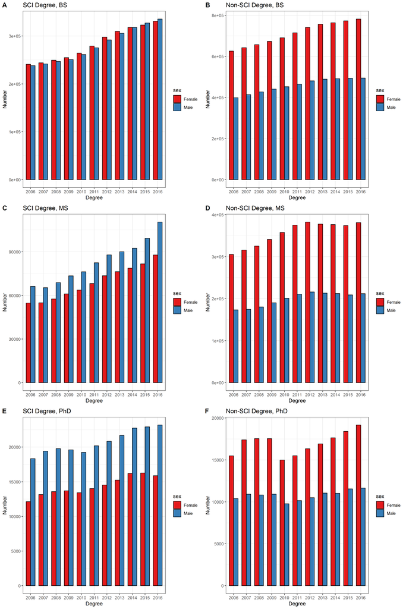

The number of all degrees granted have a increasing trend in 2006-2016, but one interesting observation is that a stagnation in PhD degree granted in 2007-2010 emerged in both SCI and non-SCI field. There was even a sharp drop in 2010 in non-SCI field.

## 2.5 Focus on Data Science

```r
degreedata[, datasci := field %in% c("Computer sciences","Mathematics and statistics")]
summary.ds = degreedata[,
                             .(number = sum(number)),
                             by = .(sci,datasci,sex,year)]
summary.ds.timeagg = summary.ds[,.(number = sum(number)),by = .(sci,datasci,sex)]
summary.ds.timeagg[, percent := number/sum(number),by = .(datasci,sci)]

# sci vs non-sci: we have conclusions before. We want to know whether it's more severe in ds compared to other sci.
summary.ds.timeagg.wide = data.frame(acast(summary.ds.timeagg[sci==T],datasci~sex,value.var = "number"))
rownames(summary.ds.timeagg.wide) = c("non-data sci"," data sci")
summary.ds.timeagg.wide = mutate(summary.ds.timeagg.wide,Female.per =
                                paste(sprintf('%0.1f',round(summary.ds.timeagg$percent[1:2]*100,digits = 1)),"%",sep = ""))

# summary table
kbl(summary.ds.timeagg.wide, caption = "Summary Statistics for Degrees Granted in SCI Field by Sex", digits = 2, booktabs = T,align = "lccc") %>%
  kable_styling(latex_options = c("HOLD_position"))%>%
   footnote(general = "The table reports the summary statistics for the amount of sci degrees granted over the sample period, separated by sex and data science or not.",
            threeparttable = T)

# barplot
ggplot(summary.ds.timeagg[sci==T],aes(x=datasci,weight=number,fill=sex))+
  geom_bar(color = "black", width = .7,position = 'dodge')+
  theme_classic()+
  ylab('Number')+
  xlab('data science')+
  scale_fill_brewer(palette = "Set1")+
  labs(title = "The Barplot of Degrees Granted in SCI Field, by Sex")
```

Since we have explored the comparison between SCI and non-SCI field, here we focus on the comparison between data science field and non-data science field within SCI field. It can be seen from the summary statistics table and the barplot aggregated all degrees and all years that the proportion of females granted degrees in data science field is significantly smaller than that in other SCI field. An absolute value of only 27.1% indicates a severe undderrepresentation for females in data science.

```r
# aggregate fields
agg.field.scionly = degreedata[sci==T,.(
  number = sum(number)
),by = .(degree,sex,year,datasci)]

# make more plots
# bs
plot.datasci.bs = ggplot(data = agg.field.scionly[datasci==T&degree=="BS"],aes(x=as.factor(year),weight = number,
                                                               fill=sex)) +
  geom_bar(color = "black", width = .7, position = "dodge") +
  labs(title = "Data SCI Degree, BS")+
  ylab("Number")+
  xlab("Degree")+
  scale_fill_brewer(palette = "Set1")+
  theme_bw()

plot.nondatasci.bs = ggplot(data = agg.field.scionly[datasci==F&degree=="BS"],aes(x=as.factor(year),weight = number,
                                                               fill=sex)) +
  geom_bar(color = "black", width = .7, position = "dodge") +
  labs(title = "Non-data SCI Degree, BS")+
  ylab("Number")+
  xlab("Degree")+
  scale_fill_brewer(palette = "Set1")+
  theme_bw()
#ms
plot.datasci.ms = ggplot(data = agg.field.scionly[datasci==T&degree=="MS"],aes(x=as.factor(year),weight = number,
                                                               fill=sex)) +
  geom_bar(color = "black", width = .7, position = "dodge") +
  labs(title = "Data SCI Degree, MS")+
  ylab("Number")+
  xlab("Degree")+
  scale_fill_brewer(palette = "Set1")+
  theme_bw()

plot.nondatasci.ms = ggplot(data = agg.field.scionly[datasci==F&degree=="MS"],aes(x=as.factor(year),weight = number,
                                                               fill=sex)) +
  geom_bar(color = "black", width = .7, position = "dodge") +
  labs(title = "Non-data SCI Degree, MS")+
  ylab("Number")+
  xlab("Degree")+
  scale_fill_brewer(palette = "Set1")+
  theme_bw()
#phd
plot.datasci.phd = ggplot(data = agg.field.scionly[datasci==T&degree=="PhD"],aes(x=as.factor(year),weight = number,
                                                               fill=sex)) +
  geom_bar(color = "black", width = .7, position = "dodge") +
  labs(title = "Data SCI Degree, PhD")+
  ylab("Number")+
  xlab("Degree")+
  scale_fill_brewer(palette = "Set1")+
  theme_bw()

plot.nondatasci.phd = ggplot(data = agg.field.scionly[datasci==F&degree=="PhD"],aes(x=as.factor(year),weight = number,
                                                               fill=sex)) +
  geom_bar(color = "black", width = .7, position = "dodge") +
  labs(title = "Non-data SCI Degree, PhD")+
  ylab("Number")+
  xlab("Degree")+
  scale_fill_brewer(palette = "Set1")+
  theme_bw()

grid.datasci = plot_grid(plot.datasci.bs,plot.nondatasci.bs,plot.datasci.ms,plot.nondatasci.ms,plot.datasci.phd,plot.nondatasci.phd,labels = "AUTO",nrow = 3)
ggsave(grid.datasci,filename = "graphs/grid_datascivsnondatasci.png",width = 12,height = 18)
```

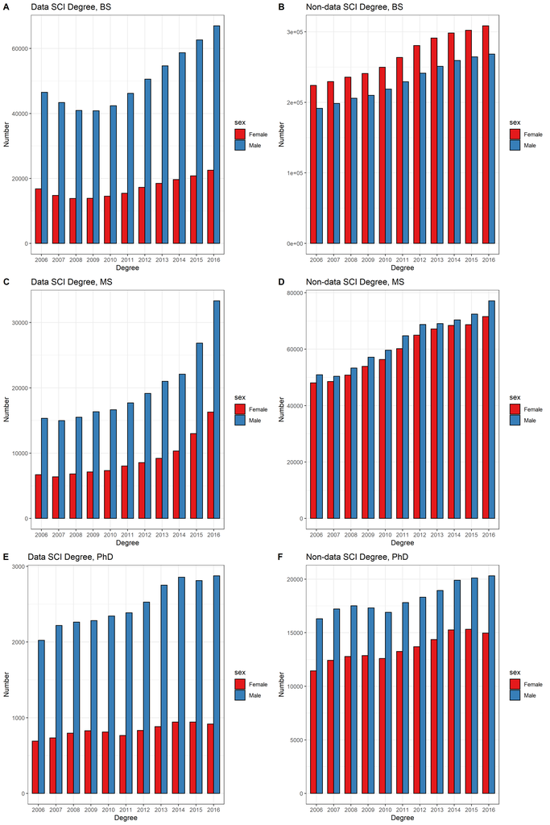

```r
### By Degree
##
summary.ds.bs = degreedata[sci==TRUE&degree=="BS",.(
  number = sum(number)
), by = .(datasci,sex)]
summary.ds.bs[, percent := number/sum(number),by = .(datasci)]
summary.ds.ms = degreedata[sci==TRUE&degree=="MS",.(
  number = sum(number)
), by = .(datasci,sex)]
summary.ds.ms[, percent := number/sum(number),by = .(datasci)]
summary.ds.phd = degreedata[sci==TRUE&degree=="PhD",.(
  number = sum(number)
), by = .(datasci,sex)]
summary.ds.phd[, percent := number/sum(number),by = .(datasci)]

# sci vs non-sci: we have conclusions before. We want to know whether it's more severe in ds compared to other sci.
summary.ds.bs.wide = data.frame(acast(summary.ds.bs,datasci~sex,value.var = "number"))
rownames(summary.ds.bs.wide) = c("non-data sci"," data sci")
summary.ds.bs.wide = mutate(summary.ds.bs.wide,Female.per =
                                paste(sprintf('%0.1f',round(summary.ds.bs$percent[1:2]*100,digits = 1)),"%",sep = ""))
summary.ds.ms.wide = data.frame(acast(summary.ds.ms,datasci~sex,value.var = "number"))
rownames(summary.ds.ms.wide) = c("non-data sci"," data sci")
summary.ds.ms.wide = mutate(summary.ds.ms.wide,Female.per =
                                paste(sprintf('%0.1f',round(summary.ds.ms$percent[1:2]*100,digits = 1)),"%",sep = ""))
summary.ds.phd.wide = data.frame(acast(summary.ds.phd,datasci~sex,value.var = "number"))
rownames(summary.ds.phd.wide) = c("non-data sci"," data sci")
summary.ds.phd.wide = mutate(summary.ds.phd.wide,Female.per =
                                paste(sprintf('%0.1f',round(summary.ds.phd$percent[1:2]*100,digits = 1)),"%",sep = ""))

# summary table
kbl(summary.ds.bs.wide, caption = "Summary Statistics for BS Degrees Granted in SCI Field by Sex", digits = 2, booktabs = T,align = "lccc") %>%
  kable_styling(latex_options = c("HOLD_position"))%>%
   footnote(general = "The table reports the summary statistics for the amount of BS sci degrees granted over the sample period, separated by sex and data science or not.",
            threeparttable = T)
kbl(summary.ds.ms.wide, caption = "Summary Statistics for MS Degrees Granted in SCI Field by Sex", digits = 2, booktabs = T,align = "lccc") %>%
  kable_styling(latex_options = c("HOLD_position"))%>%
   footnote(general = "The table reports the summary statistics for the amount of MS sci degrees granted over the sample period, separated by sex and data science or not.",
            threeparttable = T)
kbl(summary.ds.phd.wide, caption = "Summary Statistics for PhD Degrees Granted in SCI Field by Sex", digits = 2, booktabs = T,align = "lccc") %>%
  kable_styling(latex_options = c("HOLD_position"))%>%
   footnote(general = "The table reports the summary statistics for the amount of PhD sci degrees granted over the sample period, separated by sex and data science or not.",
            threeparttable = T)

# barplot
ggplot(summary.ds.bs,aes(x=datasci,weight=number,fill=sex))+
  geom_bar(color = "black", width = .7,position = 'dodge')+
  theme_classic()+
  ylab('Number')+
  xlab('data science')+
  scale_fill_brewer(palette = "Set1")+
  labs(title = "The Barplot of BS Degrees Granted in SCI Field, by Sex")
ggplot(summary.ds.ms,aes(x=datasci,weight=number,fill=sex))+
  geom_bar(color = "black", width = .7,position = 'dodge')+
  theme_classic()+
  ylab('Number')+
  xlab('data science')+
  scale_fill_brewer(palette = "Set1")+
  labs(title = "The Barplot of MS Degrees Granted in SCI Field, by Sex")
ggplot(summary.ds.phd,aes(x=datasci,weight=number,fill=sex))+
  geom_bar(color = "black", width = .7,position = 'dodge')+
  theme_classic()+
  ylab('Number')+
  xlab('data science')+
  scale_fill_brewer(palette = "Set1")+
  labs(title = "The Barplot of PhD Degrees Granted in SCI Field, by Sex")
```

## 2.6 Final Report

From the above analysis, we have a preliminary conclusion that females are underrepresented in SCI fields relative to non-SCI fields, which is consistent over time. It is more of this case in data science field and higher level of education.

However, this conclusion is drawn in a relative sense; it does not tell us about fairness because of lack in a prior benchmark. If we believe that a “fair” division should be half to half, we have the conclusion that males are underrepresented in non-SCI fields, and the distribution is quite fair in the whole SCI field. Therefore, we should take the conclusion in this analysis more cautiously.

One concern about the data set is that it only measures the number of degrees granted in every field. The final goal is to measure the degree females are undderrepresented in science, and the number of degrees granted is only one indicator. The performance in school is left unmeasured, and the situation beyond schooling period is also untouched.

To tailor this analysis more, we can try to incorporate the enrollment data in every field. It can measure the performance in school to some degree, combined with the degree data. We can also collect the gender data in faculty or top researchers in every field. We can get a better understanding of the situation for females in science with these additional information.

# 3 Case Study 3: Major League Baseball

## 3.1 Data Preparation

```r
rm(list = ls())
paydata.wide = fread("data/MLPayData_Total.csv", encoding = "UTF-8")
setnames(paydata.wide,"Team.name.2014","team")

paydata.long = fread("data/baseball.csv", encoding = "UTF-8")
```

```r
# test conversion
# paydata.wide[,.(p1998:p2014)] # do not try to use .() and : simultaneously. otherwise return a vector step by +1

# pay = paydata.wide[,team,p1998:p2014] %>%
#   pivot_longer(cols = p1998:p2014,
#                names_prefix = "p",
#                names_to = "year",
#                values_to = "payroll")
# win.num = paydata.wide[,team,X1998:X2014] %>%
#   pivot_longer(cols = X1998:X2014,
#                names_prefix = "X",
#                names_to = "year",
#                values_to = "win.num")
# win.per = paydata.wide[,team,X1998.pct:X2014.pct] %>%
#   pivot_longer(cols = X1998.pct:X2014.pct,
#                names_prefix = "X",
#                names_to = "year",
#                values_to = "win.pct") %>%
#   mutate(year = substr(year,1,4))
# test.long = pay %>%
#   right_join(win.num, by = c("year","team")) %>%
#   right_join(win.per, by = c("year","team"))
```

```r
# create increments
paydata.long[order(team,year),log.pay := log(payroll)]
paydata.long[,pay.diff := c(NA,diff(payroll)),by = team]
paydata.long[,log.pay.diff := c(NA,diff(log.pay)),by = team]
paydata.new = paydata.long[,.(team,year,diff_log=log.pay.diff,win_pct)]
```

The log difference is more appropriate in this setup because it measures the proportional (relative) change in the payroll. The base payrolls in all teams are not the same, so a same increase in absolute amount may incentivize players differently in different teams; the incentive may be bigger in teams with a smaller payroll, but smaller in teams with a larger payroll. The relative changes measured by the difference of logarithm of payroll can alleviate this problem.

## 3.2 Exploratory Questions

```r
increase.data = paydata.long[year %in% 2010:2014,.(
  log.pay.increase = log.pay[length(log.pay)]-log.pay[1], # from 2010 to 2014, increase in log(payroll)
  pay.increase = payroll[length(payroll)]-payroll[1],
  win.pct.increase = win_pct[length(win_pct)]-win_pct[1]
), by = team]
```

**Top 5 increase in log(payroll)**

```r
increase.data %>%
  filter(rank(-log.pay.increase)<6) %>%
  select(team) # top 5 teams in log(payroll) increase
```

The teams presented above are the top five teams experiencing the largest increase in log(payroll) in 2010-2014.

**Top 5 increase in payroll**

```r
increase.data %>%
  filter(rank(-pay.increase)<6) %>%
  select(team) # top 5 teams in payroll increase
```

The teams presented above are the top five teams experiencing the largest increase in payroll, i.e., the absolute value of payroll in 2010-2014. Four out of five have appeared in the top 5 lists in log(payroll) increase.

**Top 5 increase in winning percentage**

```r
increase.data %>%
  filter(rank(-win.pct.increase)<6) %>%
  select(team) # top 5 teams in winning percentage increase
```

The teams presented above are the top five teams experiencing the largest increase in winning percentage in 2010-2014.

## 3.3 Prediction

Overall, the evidence supporting that the higher increases in payroll on the log scale lead to increased performance is not clear.

```r
# 2010-2014
ggplot(increase.data,aes(x=pay.increase,y=win.pct.increase))+
  geom_point(color="blue",size=1.5)+
  geom_smooth(method = "lm",formula = y~x, color="red")+
  geom_text_repel(aes(label = team))+
  xlab("increase in payroll, 2010-2014")+
  ylab("increase in winning percentage, 2010-2014")+
  theme_bw()+
  labs("Relationship between Payroll Increase and Performance Increase, 2010-2014")
```

In 2010-2014, the increase in winning percentage seems to be positively correlated with the increase in payroll. However, it is not statistically significant because y=0 is within the error bound.

```r
# all years, year-on-year basis
paydata.long[,diff_win_pct := c(NA,diff(win_pct)), by = team]

ggplot(paydata.long,aes(x=log.pay.diff,y=diff_win_pct))+
  geom_point(color="blue",size=1.5)+
  geom_smooth(method = "lm", formula = y~x, color="red")+
  xlab("increase in payroll, year on year")+
  ylab("increase in winning percentage, year on year")+
  theme_bw()+
  labs("Relationship between Payroll Increase and Performance Increase, All Years")
```

**Regression, diff_win_pct~diff_log_pay, current period**

```r
summary(lm(diff_win_pct~log.pay.diff,data = paydata.long)) # not significant
```

Next we use the data in all years to figure out the correlation between increase in winning percentage and increase in payroll. Both the qualitative result from the scatter plot and the quantitative result from the regression are consistent with the conclusion above, that is, the positive predictive power for increase in payroll to increase in winning percentage is weak and not significant.

```r
# how about next year?
paydata.long[,diff_win_pct_next := c(diff(win_pct),NA), by = team]

ggplot(paydata.long,aes(x=log.pay.diff,y=diff_win_pct_next))+
  geom_point(color="blue",size=1.5)+
  geom_smooth(method = "lm", formula = y~x, color="red")+
  xlab("increase in payroll, year on year")+
  ylab("increase in winning percentage next year, year on year")+
  theme_bw()+
  labs("Relationship between Payroll Increase and Performance Increase Next Year, All Years")
```

**Regression, diff_win_pct~diff_log_pay, lag 1**

```r
summary(lm(diff_win_pct_next~log.pay.diff,data = paydata.long)) # negative and not significant
```

If the underlying driven force for the positive correlation between payroll increase and winning percentage increase is the introduction of better players,the correlation is most plausibly expected in the current period. However, according to the efficient wage theory, one may argue that the increase in payroll is to incentivize the current players; if they do not work harder, they may lose their well-paid positions. The positive correlation may lie between payroll increase and lagged winning percentage in this case, since it takes time for players to respond to the incentives. We test this hypothesis with a lag of one year. The result does not approve of this hypothesis, either.

## 3.4 Comparison

We test the preditive power of three alternatives in addition: payroll to winning percentage (a replication of the one we’ve seen in class), payroll to increase in winning percentage next year, and payroll to increase in winning percentage current year.

**payroll to winning percentage**

```r
ggplot(paydata.long,aes(x=log.pay,y=win_pct))+
  geom_point(color="blue",size=1.5)+
  geom_smooth(method = "lm", formula = y~x, color="red")+
  xlab("log payroll")+
  ylab("winning percentage")+
  theme_bw()+
  labs("Relationship between Payroll and Performance, All Years")
summary(lm(win_pct~log.pay,data = paydata.long)) # good prediction
```

**payroll to increase in winning percentage, next year**

```r
ggplot(paydata.long,aes(x=log.pay,y=diff_win_pct_next))+
  geom_point(color="blue",size=1.5)+
  geom_smooth(method = "lm", formula = y~x, color="red")+
  xlab("log payroll")+
  ylab("increase in winning percentage next year, year on year")+
  theme_bw()+
  labs("Relationship between Payroll and Performance Increase Next Year, All Years")
summary(lm(diff_win_pct_next~log.pay,data = paydata.long)) # not bad prediction? can be spurred
```

**pay roll to increase in winning percentage, current year**

```r
ggplot(paydata.long,aes(x=log.pay,y=diff_win_pct))+
  geom_point(color="blue",size=1.5)+
  geom_smooth(method = "lm", formula = y~x, color="red")+
  xlab("log payroll")+
  ylab("increase in winning percentage, year on year")+
  theme_bw()+
  labs("Relationship between Payroll and Performance Increase Next Year, All Years")
summary(lm(diff_win_pct~log.pay,data = paydata.long)) # not bad prediction? can be spurred

# The last two prediction power should be taken cautiously. It may stem from some rising small teams
```

Overall, current payroll predicts current performance well. As for changes in performance, there is weak evidence that increase in current performance is positively correlated to increase in payroll, but still not very predictive. It is surprising that the increase in performance, no matter current or future, is negatively correlated with the current payroll, to some degree. However, we should be cautious about this conclusion as it may be mainly driven by some rising small teams.

One more thing to note is that correlation does not mean causality. Even if our finding is that the increase in payroll is significantly positively correlated to the increase in winning percentage, we cannot say that it is causality. Just like what we point out in the last section, the introduction of better players or coaches is possibly their common parent.

```r
save.image("hw1.RData")
```